# Project 1

2024-03-24

## What we are Solving?

- Acquiring thorough profit insights is critical in the current competitive online shopping platform scenario. These insights are crucial for developing successful sales tactics and offers, which in turn lead to higher sales and more profits.
- We built a set of functions using linear regression, Elastic Net model, neural network model and Random Forest model on top of Amazon sales data. With the use of these features, we can identify weekly profit trends depending on consumer actions. Our ability to accurately and precisely improve sales performance can be enhanced by utilizing this analytical method.

**Question: Can we develop a profit function using the provided sales data that offers insights into profitability, considering various aspects such as purchase day, repeat purchases, and product categories?**

## Libraries

Four distinct models were utilized in the search for the best function, hence a large number of libraries were required.

```r
suppressWarnings({
library(ggplot2)
library(dplyr)
library(tidyr)
library(readxl)
library(nnet)
library(modelr)
library(tidyverse)
library(glmnet)
library(randomForest)
library(knitr)
library(caret)
library(kableExtra)
})
```

## Importing Data

We used read_excel to import the data and altered the column names for more practical purposes..

```r
sales.data <- read_excel("Amazon_2_Raw.xlsx")
colnames(sales.data) <- c("order_id","order_date","ship_date","email","geography","category","product_name",
                          "sales","quantity","profit")
```

## Data Preprocessing and Feautre Engineering

It is necessary to organize the data in the right format because there are numerous figures and information that were separated.

```r
sales.data$order_date <- as.Date(sales.data$order_date)
sales.data$ship_date <- as.Date(sales.data$ship_date)
sales.data$year <- format(sales.data$order_date, "%Y")
sales.data$month <- format(sales.data$order_date, "%m")
sales.data$day_of_week <- weekdays(sales.data$order_date)
sales.data$shipping_duration <- as.numeric(difftime(sales.data$ship_date, sales.data$order_date,
                                                    units = "days"))
sales.data$year <- as.factor(sales.data$year)
sales.data$month <- as.factor(sales.data$month)
sales.data$day_of_week <- as.factor(sales.data$day_of_week)
sales.data$category <- as.factor(sales.data$category)
sales.data$sales_normalized <- scale(sales.data$sales)
sales.data$quantity_normalized <- scale(sales.data$quantity)
sales.data$shipping_duration_normalized <- scale(sales.data$shipping_duration)
sales.data$order_day <- weekdays(as.Date(sales.data$order_date))
sales.data$repeat_purchases <- ave(sales.data$order_id, sales.data$email, FUN = length)
sales.data$repeat_purchases <- as.numeric(as.character(sales.data$repeat_purchases))
sales.data$repeat_purchases_normalized <- scale(sales.data$repeat_purchases)
sales.data$State <- sapply(strsplit(as.character(sales.data$geography), ","), function(x) x[3])
```

## Customer Purchase Frequency

We want to analyze customer purchasing behavior over time, specifically identifying peak periods of purchases and lows throughout the year. I utilized a line graph plot for easy visualization of the peaks and troughs in customer purchasing patterns.

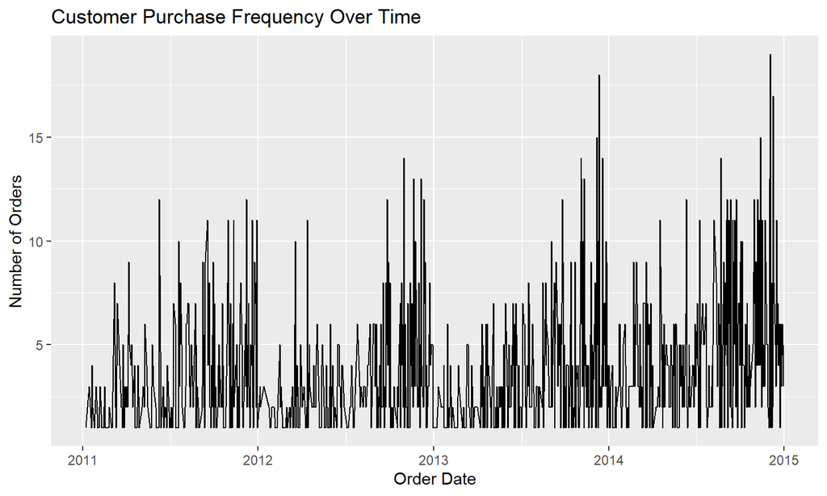

## Total sales with respect to categories

- **Varied Sales Volume**: The bar chart demonstrates significant variation in total sales among categories, with ‘Chairs’ and ‘Phones’ leading in sales volume.
- **Focus Areas for Growth**: Categories such as ‘Fasteners’, ‘Envelopes’, and ‘Labels’ show lower sales, potentially indicating areas for strategic sales initiatives or product development.

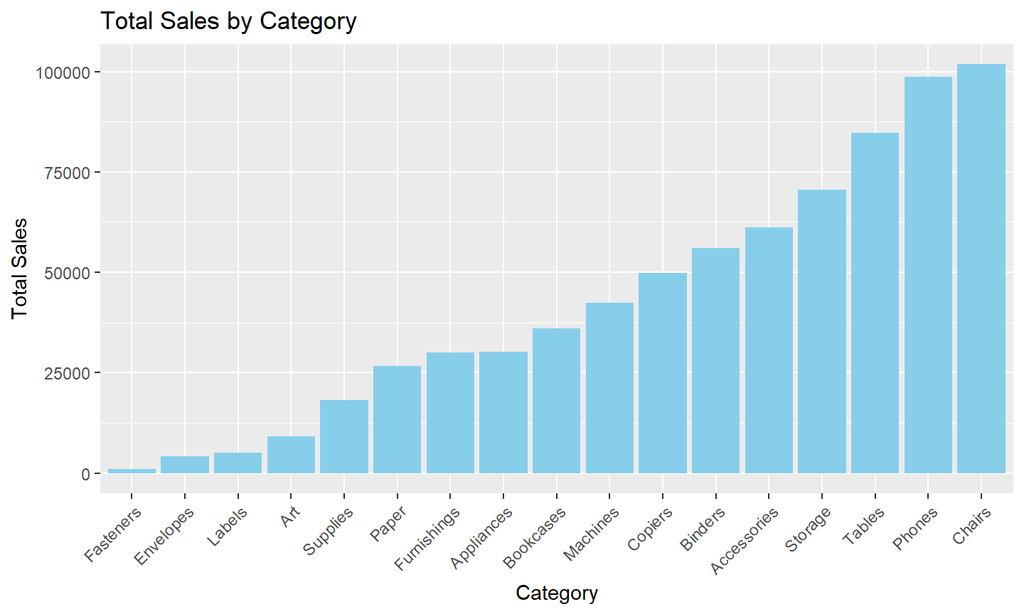

## Total profit with respect to categories

- **Profit Leaders**: ‘Copiers’ and ‘Accessories’ categories show the highest total profit, indicating strong performance and possibly higher margins.
- **Areas for Improvement**: ‘Bookcases’ and ‘Machines’ represent the lowest profit categories, suggesting a need for a review of pricing strategies, cost control, or sales tactics.

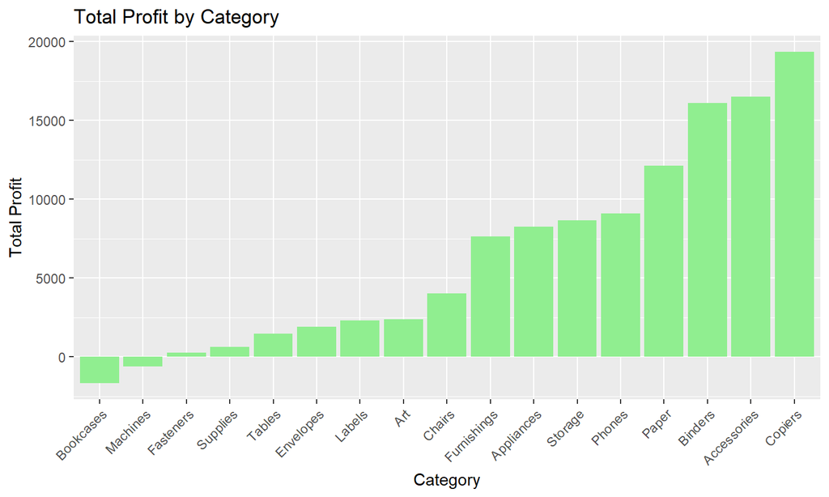

## Time Series Analysis

Long term sales have increased but short-term behavior has been volatile. Profit, however, has been steady with a spike in early 2014. This data shows how Amazon has performed over time and can be used to predict its future value.

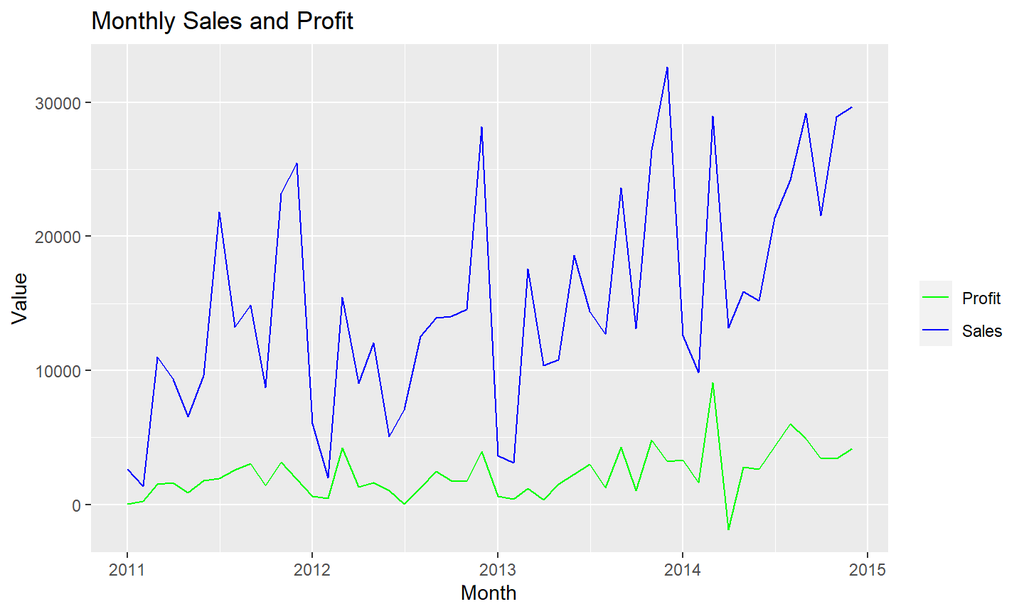

## Geographical Analysis

After geographical analysis, California orders the most Amazon products by far. Washington is second, with the other states ordering similar amounts. This data could help Amazon build more facilities in California, where product demand is higher.

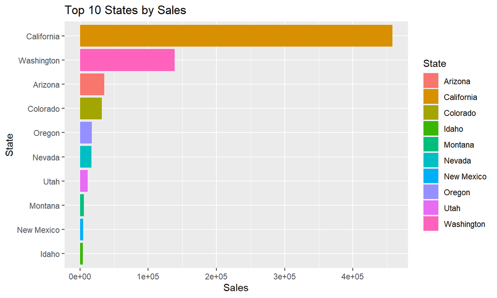

## Product Performance Analysis

The dual-axis plot above shows sales and profit by product category, with bars representing sales and lines with markers representing profit. This visualization shows how sales translate into profit across product categories. From the plot, we can see each category’s sales and profit, which may help us decide which product categories to focus on or expand.

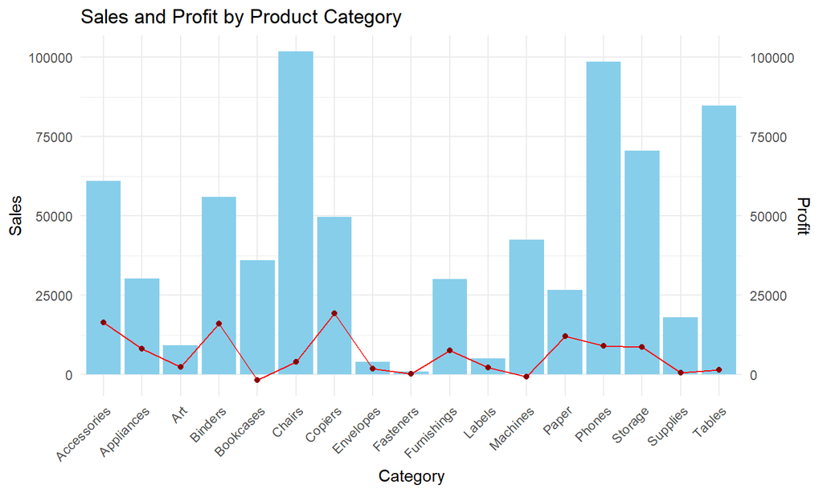

## Linear Regression

- The linear regression model uses `category`, `repeat_purchases`, and `quantity` as predictors to estimate `profit`.
- The Mean Absolute Error (MAE) is 47.39, indicating that the model’s predictions are, on average, $47.39 away from the actual profit values.
- The Mean Squared Error (MSE) is reported at 25325.26, suggesting that the model’s predictions are quite variable and may be influenced by outliers or extreme values.
- The R-squared value of the model is 0.1643, which means that about 16.43% of the variation in `profit` is explained by the model. This is a relatively low value, implying that the model might not be capturing all the factors that influence profit.

Regression Coefficients

|  | Estimate | Std. Error | t value | Pr(>&#124;t&#124;) |
| --- | --- | --- | --- | --- |
| (Intercept) | 36.5942481 | 12.16953 | 3.0070395 | 0.0026587 |
| categoryAppliances | -0.2338952 | 16.95187 | -0.0137976 | 0.9889923 |
| categoryArt | -52.2662349 | 14.19648 | -3.6816324 | 0.0002356 |
| categoryBinders | -29.4721954 | 12.38528 | -2.3796157 | 0.0173893 |
| categoryBookcases | -83.3536152 | 20.46702 | -4.0725814 | 0.0000476 |

Regression Coefficients (Part 2)

|  | Estimate | Std. Error | t value | Pr(>&#124;t&#124;) |
| --- | --- | --- | --- | --- |
| categoryChairs | -41.2227905 | 14.9351472 | -2.7601195 | 0.0058111 |
| categoryCopiers | 712.2774064 | 33.5139968 | 21.2531323 | 0.0000000 |
| categoryEnvelopes | -30.6072988 | 21.9446809 | -1.3947480 | 0.1631892 |
| categoryFasteners | -57.4140393 | 21.3177668 | -2.6932483 | 0.0071130 |
| categoryFurnishings | -37.8312663 | 13.5376149 | -2.7945296 | 0.0052286 |
| categoryLabels | -45.1677310 | 17.8774378 | -2.5265215 | 0.0115679 |
| categoryMachines | -77.7972172 | 27.4784041 | -2.8312131 | 0.0046663 |
| categoryPaper | -35.3718518 | 12.4901703 | -2.8319751 | 0.0046552 |
| categoryPhones | -29.9577117 | 13.8375138 | -2.1649635 | 0.0304645 |
| categoryStorage | -30.8623088 | 13.9770623 | -2.2080683 | 0.0273105 |
| categorySupplies | -50.8745020 | 21.6850309 | -2.3460655 | 0.0190338 |
| categoryTables | -52.6158093 | 17.8954235 | -2.9401824 | 0.0033038 |
| repeat_purchases | -0.3366328 | 0.6724205 | -0.5006283 | 0.6166673 |
| quantity | 7.4423722 | 1.2536158 | 5.9367251 | 0.0000000 |

## Interpretation

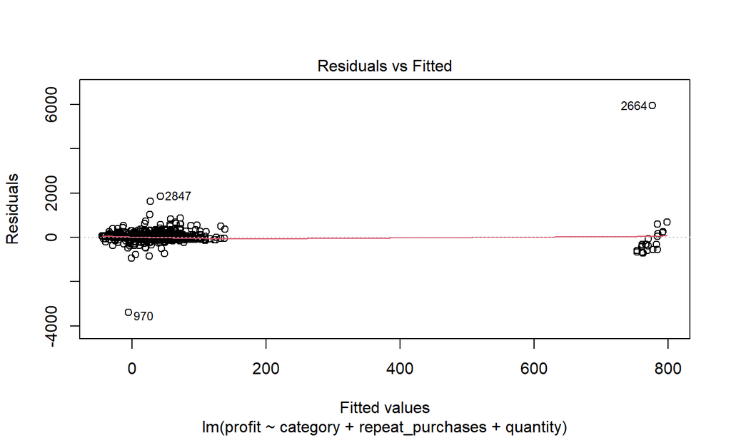

## Normal Q-Q Plot

- **Distribution issues**: The tail of the plot curves upwards, thus not a normal distribution.
- **Influential observations**: Points like 2664 stray from the expected line, possibly exerting undue influence on the model.

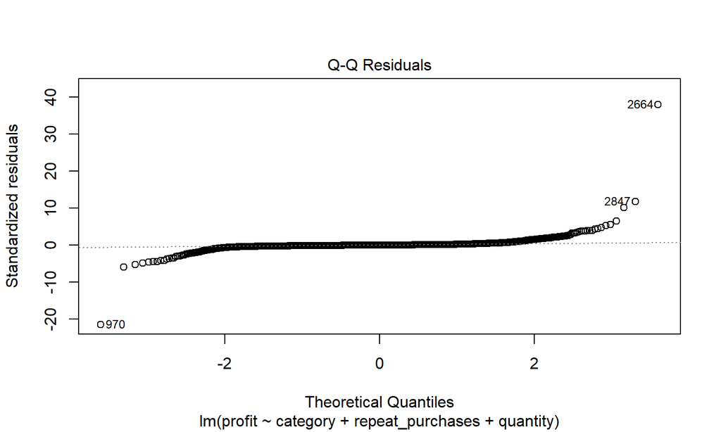

## Neural Network with k fold

### Neural Network Training Introduction

- Goal: Predict `target` using a neural network model.
- Data: Features prepared from `sales.data`.
- Method: 5-fold cross-validation to evaluate model performance.

### Data Preparation and Model Configuration

- Data matrix: `data_for_nn` prepared with predictors.
- Target variable: `profit` from `sales.data`.
- Neural network setup: `nnet` with size=5, decay=0.000005, max iterations=3000.

## Neural Network Training Summary

### Training Output Summary for Each Fold

- **Fold 1**: Initial value: 44,034,439.54 | Final value: 35,729,033.63
- **Fold 2**: Initial value: 88,105,695.11 | Final value: 58,442,771.49
- **Fold 3**: Initial value: 93,857,949.85 | Final value: 71,036,755.92
- **Fold 4**: Initial value: 94,524,748.27 | Final value: 74,115,030.54
- **Fold 5**: Initial value: 82,663,911.40 | Final value: 56,772,514.61

### Average Performance Across All Folds

- **Average Mean Absolute Error (MAE) across all folds:** 50.21544
- **Average Mean Squared Error (MSE) across all folds:** 31,663.92

## Regression using Elastic Net model

**Elastic Net Model Overview**

- **Hybrid Model**: Combines Lasso and Ridge attributes with alpha at 0.5.
- **Average Error**: MAE of $39.38 shows the model’s close-fit predictions.

**Model Performance**

- **Precision**: An MSE of 13,956.61 reflects a robust predictive accuracy.
- **Explained Variance**: R-squared value at 53.94%, a substantial fit indicating the model’s effectiveness.

## Actual vs Predicted Plot (Elastic Net model)

**Prediction Alignment**: “Actual vs. Predicted” visuals show many predictions closely match actual profits.

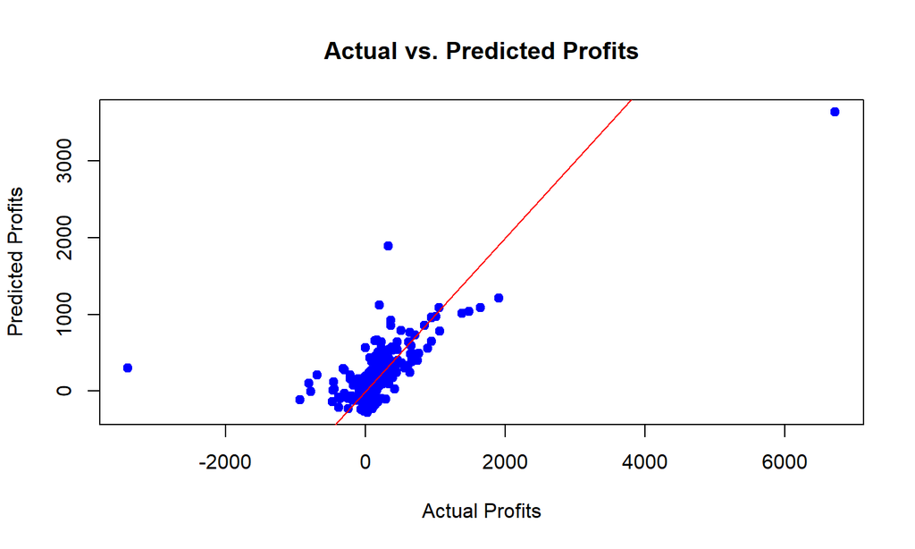

## Residual Plot (Elastic Net model)

**Residual Trends**: “Residual Plot” reveals patterns suggesting the influence of outliers on prediction accuracy.

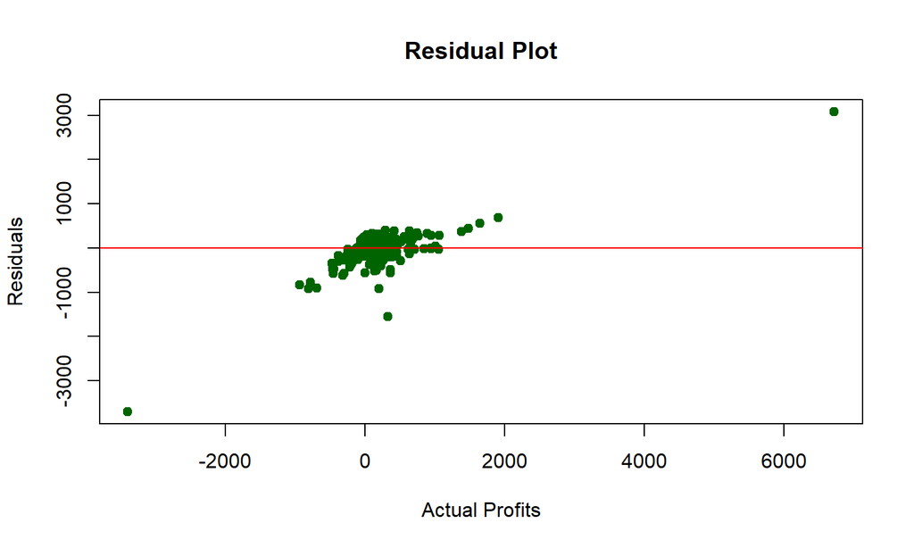

## Random Forest

- **High Variance Explained**: With an R-squared of 85.5%, the model accounts for a significant portion of profit variance.
- **Model Complexity**: Utilizes 500 trees to achieve strong predictive accuracy and fit.

```
## Random Forest - Mean Absolute Error (MAE): 13.73329
```

```
## Random Forest - Mean Squared Error (MSE): 4395.276
```

```
## R-squared: 0.854963
```

## Actual vs Predicted Plot (Random Forest)

The “Actual vs. Predicted Profits (Random Forest)” plot illustrates a tight clustering of points along the red line that indicates perfect predictions, demonstrating the model’s accuracy in predicting profits.

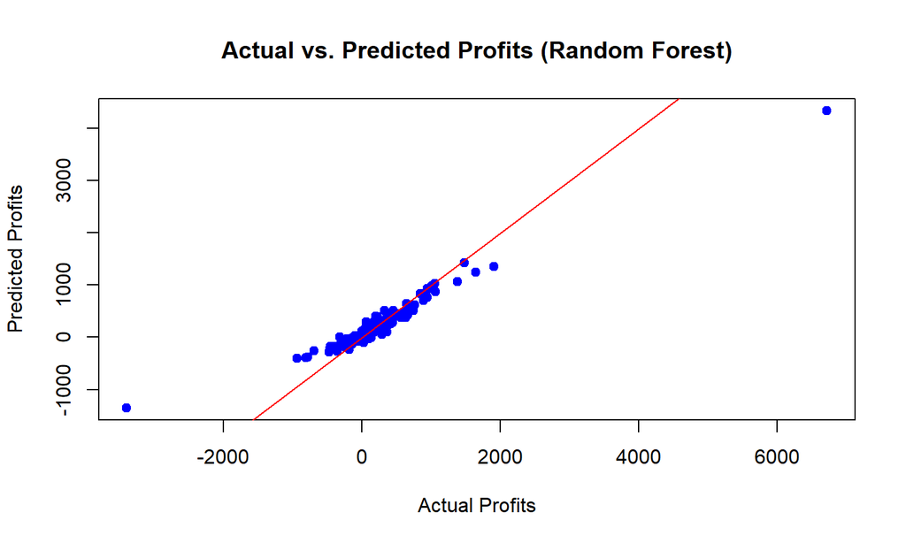

## Residual Plot (Random Forest)

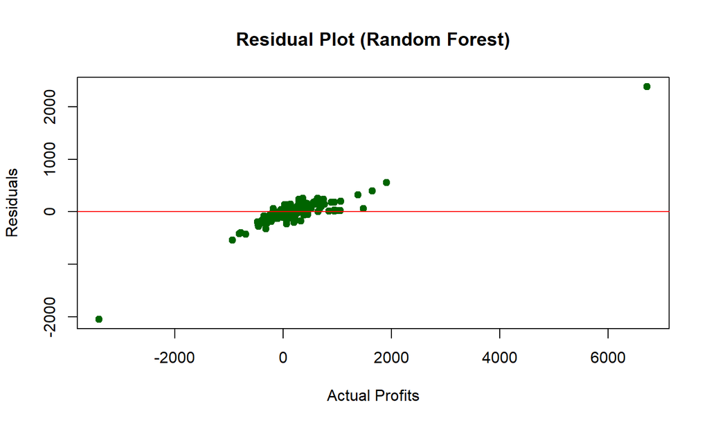